## Week 2 : BP models & interactions in GLM. Lab: markdown

[output not shown]

### Tuesay session

- Jeopardy!

### Mplus & Centering

- Quiz questions

### Extra credit

You can earn extra credit by researching and sharing online resources that could be of use in preparing this week’s report. This week’s theme : **online resources for learning markdown**. Vote only if you find this resource useful

#### Non-competitive EC

- post as a reply to “EXTRA CREDIT” comment thread at the bottom of this page
- get 1 point if posted before 23:59 Friday

#### Competitive EC

- best 5 posts (measured by the end of the lab on Friday) get another 1 EC points

### Report due

**Assignment** Summarize the first two chapters in a markdown report. Use this [cheatsheet](http://support.mashery.com/docs/customizing_your_portal/Markdown_Cheat_Sheet) to ensure that your report contains at least:

- 3 different headings
- 1 ordered list
- 1 unordered list
- 1 definition list
- 3 kinds of emphasis
- 1 link to a webpage
- 1 image call
- 2 tables

NOTE: You will not be graded on the content, but be prepare to discuss your work with the class.

### Markdown Resourses

Screenshot

Links & Descriptions

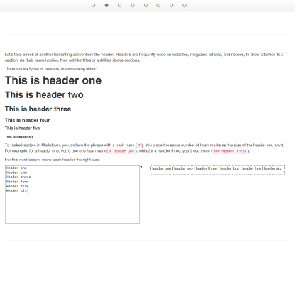

**1** [Markdwon Tutorial](http://markdowntutorial.com/) by [Garen Torikian](https://github.com/gjtorikian)

[figure not shown]

**2** [Markdown Cheatsheet](https://github.com/adam-p/markdown-here/wiki/Markdown-Cheatsheet) by [Adam Pritchard](https://github.com/adam-p)

[figure not shown]

**3** [Markdown Syntax Cheat Sheet](http://stationinthemetro.com/wp-content/uploads/2013/04/Markdown_Cheat_Sheet_v1-1.pdf) by [Mark Boszko](http://stationinthemetro.com/)

[figure not shown]

**4** [The R Markdown Cheat sheet](http://shiny.rstudio.com/articles/rm-cheatsheet.html) for dynamic reporting in RStudio by [RStudio Blog](http://blog.rstudio.org/)

[figure not shown]

**5** [Markdown quick reference](http://en.support.wordpress.com/markdown-quick-reference/) from Wordpress

[figure not shown]

**6** [Video tutorial](https://www.youtube.com/watch?v=6A5EpqqDOdk) by Stevan Wing

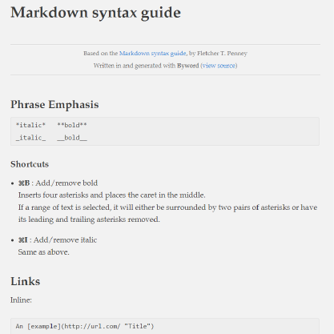

**7** [Markdown syntax guide](http://bywordapp.com/markdown/syntax.html) by Fletcher T. Penney

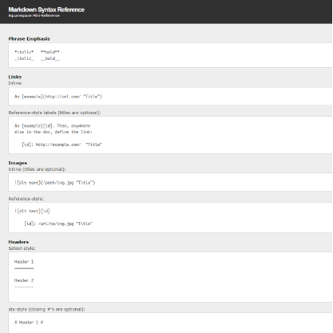

**8** [Markdown syntax reference](http://five.squarespace.com/display/ShowHelp?section=Markdown) by Squarespace

[figure not shown]

**9** [Markdown table generator](http://www.tablesgenerator.com/markdown_tables) by Table Generator

### Learning objectives: Concepts

#### Basic

- simple effect
- main effect
- contrast
- interaction

#### Intermediate

- General Linear Model
- use of dummy variables

#### Advanced

- Three-way interactions

### Learning objectives: Skills

#### Basic

- load data
- basic file types in MPlus
- reading the output

#### Intermediate

- re-center a continuous predictor
- write dummy variable

#### Advanced

- plot interactions